# ME323 - Introdução aos Modelos Probabilísticos

## Teste de Hipóteses - Introdução

## Uma senhora toma chá

[R. A. Fisher](https://pt.wikipedia.org/wiki/Ronald_Fisher) foi um dos fundadores da Estatística moderna.

Em um de seus famosos experimentos, ele testou a capacidade de uma senhora em distinguir se a xícara estava servida com o leite colocado antes ou depois do chá.

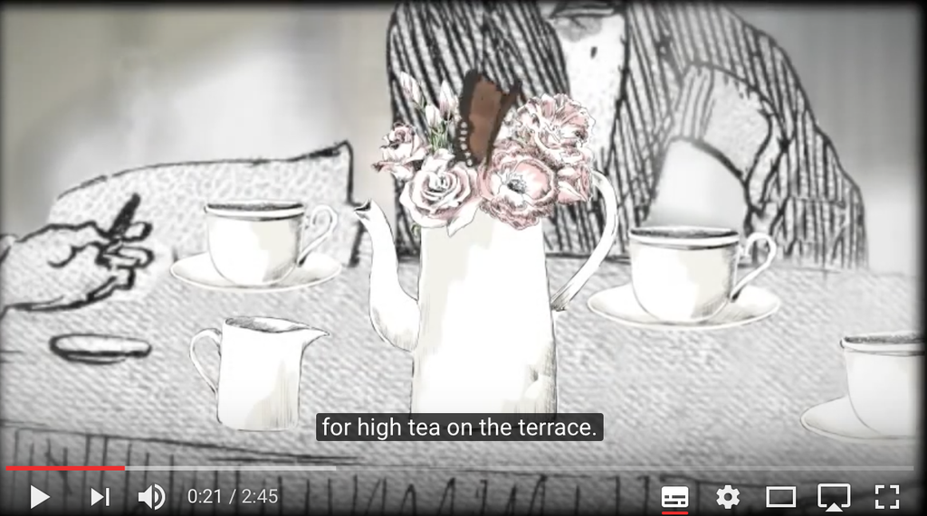

[Vídeo](https://youtu.be/lgs7d5saFFc)

## Uma senhora toma chá

Como planejar um experimento para testar a capacidade da pessoa distinguir se o chá foi preparado com leite primeiro ou por último?

- Como lidar com variações na temperatura do chá, quantidade de açúcar, entre outras?
- Quantas xícaras devem ser usadas no teste? Qual a ordem de apresentação dessas xícaras?
- Qual conclusão iremos tirar caso a pessoa erre somente uma vez? Ou duas vezes?

## Experimento

- 8 xícaras: 4 com chá colocado antes do leite e 4 com leite antes do chá.
- As oito xícaras foram apresentadas em ordem aleatória para a senhora, mas a informação de que eram 4 de cada tipo foi passada a ela.
- A senhora deveria provar a bebida das oito xícaras e escolher as 4 xícaras que acreditava estar com chá primeiro.
- Verificou-se quantas dentre as 4 xícaras ela escolheu corretamente.
- Quais os resultados possíveis do experimento?

## Resultados possíveis

- Tarefa da senhora: escolher as 4 xícaras com chá primeiro.
- São 8 xícaras: 4 com leite primeiro e 4 com chá primeiro.
- A senhora escolhe 4 dentre 8, sem reposição.
- De quantas formas ela pode fazer isso, caso ela de fato não saiba distinguir e esteja fazendo tudo ao acaso?

\[\binom{8}{4}=70\]

## Resultados possíveis

- É possível que ela escolha as 4 corretamente: 4 com chá primeiro.
- De quantas formas ela pode escolher 4 corretas?
- Para escolher 4 corretas, duas coisas devem ocorrer: escolher 4 com chá primeiro (dentre 4 com chá primeiro) e não escolher nenhuma dentre as 4 com leite primeiro.
- De quantas formas é possível fazer isso, caso ela de fato não saiba distinguir e esteja fazendo tudo ao acaso?

\[\binom{4}{4}\binom{4}{0}=1\]

## Resultados possíveis

- É possível que ela escolha 3 corretamente: 3 com chá primeiro e 1 com leite primeiro.
- De quantas formas ela pode escolher 3 corretas, caso ela de fato não saiba distinguir e esteja fazendo tudo ao acaso?

\[\binom{4}{3}\binom{4}{1}=16\]

## Resultados possíveis

- É possível que ela escolha 2 corretamente: 2 com chá primeiro e 2 com leite primeiro.
- De quantas formas ela pode escolher 2 corretas, caso ela de fato não saiba distinguir e esteja fazendo tudo ao acaso?

\[\binom{4}{2}\binom{4}{2}=36\]

## Resultados possíveis

- É possível que ela escolha 1 corretamente: 1 com chá primeiro e 3 com leite primeiro.
- De quantas formas ela pode escolher 1 correta, caso ela de fato não saiba distinguir e esteja fazendo tudo ao acaso?

\[\binom{4}{1}\binom{4}{3}=16\]

## Resultados possíveis

- É possível que ela erre todas: 0 com chá primeiro e 4 com leite primeiro.
- De quantas formas ela pode errar todas, caso ela de fato não saiba distinguir e esteja fazendo tudo ao acaso?

\[\binom{4}{0}\binom{4}{4}=1\]

## Resultados possíveis

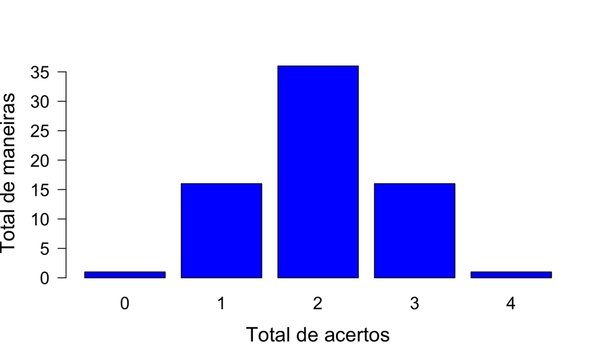

## Teste de hipótese

- \(H_0\): A senhora não consegue distinguir entre chá ou leite primeiro e escolhe ao acaso durante o experimento.
- \(H_a\): A senhora consegue distinguir.
- Estatística do teste: Total de acertos (\(X\))
- Para decidir, precisamos primeiramente da distribuição de probabilidade da estatística do teste quando \(H_0\) é verdadeira.

## Distribuição Hipergeométrica

- População dividida em duas características
- Extrações casuais sem reposição
- \(N\) objetos
- \(r\) têm a característica A
- \(N-r\) têm a característica B
- um grupo de \(n\) elementos é escolhido ao acaso, dentre os \(N\) possíveis, sem reposição.

> Queremos calcular a probabilidade de que este grupo de \(n\) elementos contenha \(x\) elementos com a característica A.

## Distribuição Hipergeométrica

| Elemento escolhido | Característica \(A\) | Característica \(B\) | Total |
| --- | --- | --- | --- |
| **sim** | \(x\) | \(n-x\) | \(n\) |
| **não** |  |  | \(N-n\) |
| **Total** | \(r\) | \(N-r\) | \(N\) |

Seja \(X\) a v.a. que representa o número de elementos com a característica A dentre os \(n\) escolhidos ao acaso.

Então dizemos que \(X\) segue uma distribuição **Hipergeométrica** com parâmetros \(N,n,r\), ou seja, \(X \sim Hip(N,n,r)\).

A probabilidade de se observar \(x\) é dada por: \[P(X=x)=\frac{\binom{r}{x}\binom{N-r}{n-x}}{\binom{N}{n}}\,,\quad\quad0\leq x \leq min\{r,n\}\]

## Teste de hipótese

- População dividida em duas características: chá primeiro, leite primeiro.
- Extrações casuais sem reposição
- \(N\) objetos: 8 xícaras
- \(r\) têm a característica A: 4 com chá primeiro
- \(N-r\) têm a característica B: 4 com leite primeiro
- Um grupo de \(n\) elementos é **escolhido ao acaso**, dentre os \(N\) possíveis, sem reposição: a senhora escolhe 4 xícaras dentre as 8.

## Teste de hipótese

Queremos calcular a probabilidade de que dentre as 4 xícaras escolhidas \(x\) tenham de fato o chá colocado primeiro.

Seja \(X\) a v.a. que representa o número de xícaras com chá primeiro dentre as 4 selecionadas.

Então dizemos que \(X\) segue uma distribuição **Hipergeométrica** com parâmetros \(N,n,r\), ou seja, \(X \sim Hip(N=8,n=4,r=4)\).

A probabilidade de se observar \(x\) é dada por: \[P(X=x)=\frac{\binom{4}{x}\binom{4}{n-x}}{\binom{8}{4}}, \qquad 0\leq x \leq 4\]

## Teste de hipótese

- \(H_0\): A senhora não consegue distinguir entre chá ou leite primeiro e escolhe ao acaso durante o experimento.
- Estatística do teste: Total de acertos (\(X\))
- Distribuição de probabilidade da estatística do teste, quando \(H_0\) é verdadeira.

\[P(X=x)=\frac{\binom{4}{x}\binom{4}{4-x}}{\binom{8}{4}}, \qquad 0\leq x \leq 4\]

## Teste de Hipótese

Distribuição da Estatística do Teste sob \(H_0\)

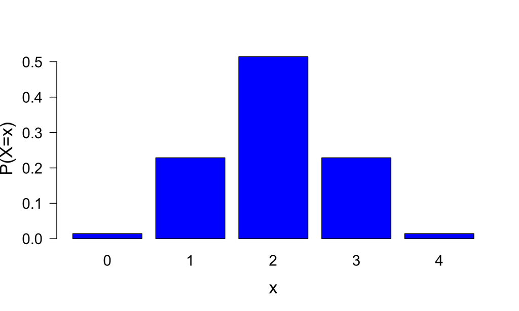

## Teste de Hipótese

Como decidir se rejeitamos ou não \(H_0\) de acordo com a estatística do teste observada?

> Como decidir se rejeitamos a hipótese de que a senhora não consegue distinguir os chás, sendo que ela acertou, por exemplo, 3? Se ela tivesse acertado todas as 4 xícaras? Seria por pura sorte? Ou ela tem algum conhecimento?

> Calculamos a probabilidade, sob \(H_0\), de um valor igual ou mais extremo ao da estatística do teste observada (**valor-de-p**). Mais extremo: mais evidência contra \(H_0\).

> Se o valor-de-p obtido é bem pequeno, por exemplo, 0.01, isto quer dizer que se \(H_0\) é verdadeira, então seria incomum obter uma amostra com os resultados como o observado.

Um valor-de-p muito baixo traz fortes evidências contra \(H_0\).

## Conclusão

Se a senhora acertou 3 xícaras:

\[P(X=3) = \frac{\binom{4}{3}\binom{4}{1}}{\binom{8}{4}}=8/35 \]

> Calculamos a probabilidade de um valor igual ou mais extremo ao da estatística do teste observada (**valor-de-p**). Mais extremo: mais evidência contra \(H_0\).

> Se a senhora tivesse acertado 4, seria ainda mais evidência contra \(H_0\), de forma que o valor de p é calculado como:

\[P(X=3)+P(X=4)=8/35 + 1/70 = 17/70\]

> Se este valor for considerado alto, não temos evidências, baseando-se no experimento realizado, para rejeitar \(H_0\).

## Leituras:

- David Salsburg - Uma senhora toma chá: Como a estatística revolucionou a ciência no século XX
- [Dama apreciadora de chá](https://pt.wikipedia.org/wiki/Dama_apreciadora_de_chá)

Slides produzidos por:

- Samara Kiihl